# Fabian_Hofmann_LAB_1

← LAB ◊ ↑ TOC ↑

**Name, Vorname:**  
Hofmann Fabian  
Richter Daniel

### Inhalt

0. Allgemeine Hinweise

1. Einführung

2. Diskrete Faltung

3. LTI-Systeme

# 0. Allgemeine Hinweise

## 0.1 Vor dem Versuch

Bitte bereiten Sie die wie folgt gekennzeichneten Blöcke *vor* dem Praktikumsversuch vor, tragen Sie Ihren Namen oben und die Antworten ins Notebook ein und speichern Sie es lokal oder auf dem Notebookserver https://notebook.gesis.org unter dem Namen "Lab1_Nachname_Vorname" (File -> Save Notebook As ...) ab.

**VORBEREITUNG:**

**Beispiel**

- Geben Sie die Systemfunktion eines Differenzierers an

$H(z) = 1 - z^{-1} = (z-1)/z$

- Welche Filter sind für die Praxis am wichtigsten?

**FIR Filter da sie Linearphasig sind** Bsp.: Differenzierer, Mittelwertsfilter

Simulationsaufgaben werden gemeinsam im Praktikum bearbeitet, sie sind gekennzeichnet durch

**SIMULATION:**

## 0.2 Tipps zum Schreiben und Coden

- \<SHIFT>-\<RETURN> führt eine Codezelle aus und rendert eine Textzelle.
- In Markdown sind Leerzeilen wichtig zum Trennen von Abschnitten!
- Sie können LaTeX-Code zwischen \$ ... \\$ einschließen.
- Kontexthilfe zu Funktionen etc. bekommen Sie über \<SHIFT>-\<TAB>

## 0.3 Nach dem Versuch

Nach dem Praktikumsversuch exportieren Sie das Notebook mit Textantworten, Codezellen und Plots als HTML (File -> Export Notebook As ... -> Export Notebook to HTML) und reichen es in Moodle ein.</div>

Abbildungen in diesem Notebook wurden konvertiert mit https://www.base64-image.de/ und in den HTML-Code eingebettet.

```python
import os, sys
module_path = os.path.abspath(os.path.join('..')) # append directory one level up to import path
if module_path not in sys.path:  # ... if it hasn't been appended already
    sys.path.append(module_path)
import dsp_fpga_lib as dsp
dsp.versions() # print versions

%matplotlib inline
import matplotlib.pyplot as plt
size = {"figsize":(12,6)} # Plotgröße in Inch

import numpy as np
import scipy.signal as sig
import wave

from IPython.display import Audio, display
```

```
Python version: 3.9.7
Numpy: 1.20.3
Scipy: 1.7.1
Matplotlib: 3.4.3 module://matplotlib_inline.backend_inline
```

# LAB 1: Intro, Faltung zeitdiskreter Signale und LTI-Systeme

## 1. Einführung

In diesem Abschnitt erstellen Sie verschiedene Signale, plotten sie und machen sie hörbar.

Zunächst generieren wir ein Sinussignal der Länge $T=2$ s und der Frequenz $f_a = 440$ Hz, das mit $f_S = 8$ kHz abgetastet wird.

Bitte bereiten Sie die wie folgt gekennzeichneten Blöcke vor dem Praktikum vor:

**VORBEREITUNG:**

- Wie viele Datenpunkte $N$ und wie viele Perioden $L$ umfasst das Signal?
  - $L = fa*T = 880 $, $N = fs*2 = 16000$
- Wie groß ist die Abtastperiode $T_S$?
  - T_s = 1/fs = 0.125 ms

## 1.1 Signalerzeugung

**SIMULATION:**

**Achtung:** Bei der Angabe von Bereichen ist in Python das letzte Element immer ausgeschlossen - `a = np.arange(10)` erzeugt ein Array mit den Zahlen 0 ... 9; `a[3:7] = [3, 4, 5, 6]`, Element Nr. 7 ist gerade eben nicht mehr dabei. Im Gegensatz zu Matlab nutzt Python 0-based indexing, d.h. das erste Element eines Arrays ist `a[0]`.

- Erzeugen Sie ein Index-Array `n` mit $N$ ganzzahligen Elementen mit der numpy Funktion `n = np.arange(end)` d.h. `n = np.arange(start, end, step)` mit den Defaultwerten `start=0` und `step=1` und `end=N`.
- Erzeugen Sie ein Zeit-Array `t` mit $N$ reellwertigen Elementen im Abstand $T_S$ über `t = np.linspace(start, end, N)` mit `end=N T_S`. Prinzipiell geht das auch mit `t = np.arange(0, N * T_S, T_S)`, hier besteht aber die Gefahr dass das Array wegen Rundungsfehlern ein Element mehr enthält als erwartet.
- Stellen Sie mit `len()` sicher, dass die Längen der beiden Vektoren identisch sind.
- Stellen Sie die Funktionen `y1 = sin( ... n)` und `y2 = sin( ... t)` so auf, dass beide Ausdrücke die gleichen Zahlenfolgen ergeben, $y1 = y2$. Was liefert der Vergleich `print(y1[:10] == y2[:10])`? Erklären Sie das Ergebnis!
- Das Herausschneiden von Bereichen aus einem Array nennt man "Slicing", siehe z.B. https://www.w3schools.com/python/numpy_array_slicing.asp . Mit Slicing kann man ziemlich kranke Dinge tun, `y[2 : -1 : -2]` gibt Ihnen z.B. rückwärts jeden zweiten Wert ("-2") eines Arrays aus, angefangen beim letzten Wert ("-1") bis zum zweiten Wert ("2"), der gerade eben nicht mehr mit dabei ist. Was liefert `a[:10]`? Und was könnte `a[10:]` bedeuten?

```python
#Variablen
N = 16000
T_s = 0.000125
f = 440
F = f/8000
#Vektor erstellen
n = np.arange(N)
t = np.linspace(0, N * T_s, len(n))
print("len n: ", len(n), "len t:", len(t))

#Signal berechnen
y1 = np.sin(2 * np.pi * F *n)
y2 = np.sin(2 * np.pi * f *t)
print(y1.astype(float))
print(y2.astype(float))
print(y1[:10] == y2[:10])
#Rundungs Fehler


#a[start:stop:step]
```

```
len n:  16000 len t: 16000
[ 0.          0.33873792  0.63742399 ... -0.86074203 -0.63742399
 -0.33873792]
[ 0.00000000e+00  3.38758243e-01  6.37457275e-01 ... -6.37457275e-01
 -3.38758243e-01  1.25522677e-13]
[ True False False False False False False False False False]
```

## 1.2 Anschauen

In der nächsten Codezelle sollen Sie die Daten plotten mit Hilfe der Funktionen `ax.plot(x,y)` oder `ax.stem(x,y)`. In das Signal "hinein zoomen" können Sie mit `ax.set_xlim([start, stop])`, dabei beziehen sich `start` und `stop` auf die Werte des Zeitvektors, nicht auf die Indizes. Mit `ax.plot(x[10:20], y[10:20])` wählen Sie indexbasiert Slices aus, die fürs Plotten gleiche Länge haben müssen. Sie können die Plots verschönern mit `ax.set_xlabel("mein Label")` (ebenso für die y-Achse) oder `ax.set_title("mein Titel")`.

Die etwas seltsam aussehende Syntax `**size` bewirkt übrigens, dass das Dictionary `size` entpackt wird und die einzelnen Schlüssel-Werte Paare an die subplots-Methode übergeben werden.

**SIMULATION:**

- Plotten Sie jetzt die Daten, indem Sie den Code der nächsten Zelle vervollständigen.
- Fügen Sie Label, Titel oder was immer Ihnen gefällt hinzu
- Testen Sie `ax.set_xlim()`, um in die Signale hinein zu zoomen.
- Zeigen Sie, dass die Signale identisch sind, indem Sie die gleichen Indizes beider Signale über einen kleinen Bereich darstellen.

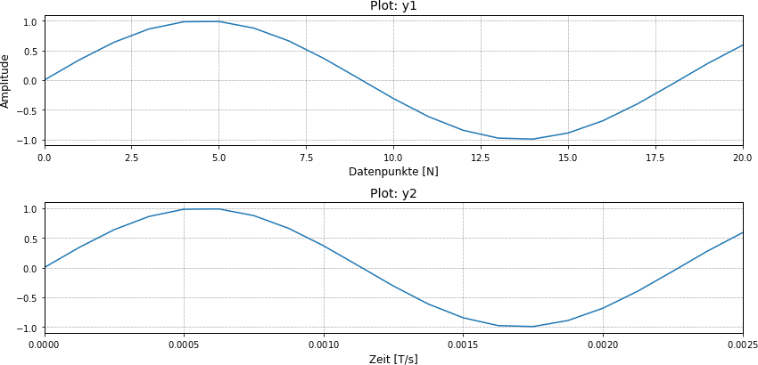

```python
fig, (ax1,ax2) = plt.subplots(2,1,**size)
#Zoom
ax1.set_xlim([n[0], n[20]])
ax2.set_xlim([t[0], t[20]])

#Label
ax1.set_title("Plot: y1")
ax1.set_xlabel("Datenpunkte [N]")
ax1.set_ylabel("Amplitude")
ax2.set_title("Plot: y2")
ax2.set_xlabel("Zeit [T/s]")
ax1.set_ylabel("Amplitude")
#Ploten
fig.tight_layout()
ax1.plot(n, y1)
ax2.plot(t, y2)
```

## 1.3 Anhören

Die Daten kann man sich im Browser anhören mit der `Audio` Klasse aus dem `IPython.display` - Modul:

`display(Audio((data=None, filename=None, url=None, embed=None, rate=None, autoplay=False)`

`data` kann dabei ein ein- oder zweidimensionales numpy-Array oder Liste sein, ein Filename oder auch eine URL. Der Parameter `rate` definiert die Abtastrate (nicht bei wav-Files, dort steht die Abtastrate im File.

```python
display(Audio(data=y2, rate=8000))
```

[interactive chart not shown]

**SIMULATION:**

Erzeugen Sie ein Stereosignal mit Hilfe eines zweiten Sinussignals mit 445 Hz und hören Sie sich das Resultat mit dem Kopfhörer an.

Sie können zwei Listen oder Arrays zusammenfügen zu einer Liste mit `list12 = [list1, list2]` oder Sie nutzen `a12 = np.vstack((a1, a2))`. Für Stereowiedergabe muss das Array die Form `(2, Anzahl_Samples_pro_Kanal)` haben

Überprüfen Sie mit den Befehlen `np.shape(a)`, `a.size`, `len(a)` oder `np.ndim(a)` Form und Dimension des entstandenen Arrays. Was macht der Befehl `np.hstack()`? -> Es verbindet zwei Array's zeilenweise.

Ein Signal transponiert man (vertauschen der Achsen) ganz einfach mit `a.T`. Falls sich ein Signal gar nicht abspielen lässt, versuchen Sie es einmal zu transponieren.

```python
y3 = np.sin(2 * np.pi * 445 * t)
print("len y2: ", len(y2), "len y3:", len(y3))

y = np.vstack((y2, y3))
print("shape y: ", np.shape(y))
display(Audio(data=y, rate=8000))
#
```

```
len y2:  16000 len y3: 16000
shape y:  (2, 16000)
```

[interactive chart not shown]

# 2 Diskrete Faltung

In diesem Versuchsteil definieren wir die Impulsantwort $h[n]$ eines zeitdiskreten Filters ausgehend von einem analogen Rechteckpuls $h(t) = \text{rect} (t/\Delta T)$ mit $\Delta T = 250\,\mu$s, der mit $f_S = 64$ kHz abgetastet wird. Die Impulsantwort ist daher eine Abfolge von $L$ Diracstößen mit gleicher Amplitude. Mit dem so definierten System filtern wir anschließend Rauschsignale.

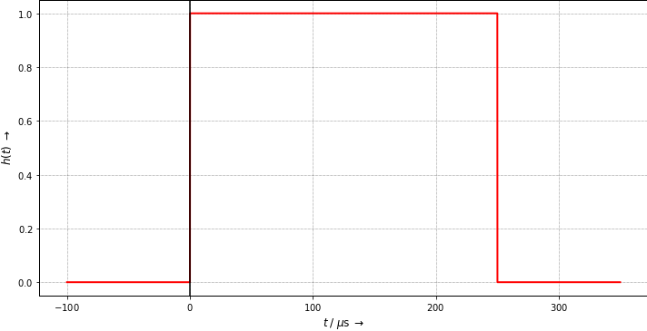

```python
fig, ax = plt.subplots(**size)
t = np.arange(-100, 350, 0.1)
ax.plot(t, np.where((t >= 0) & (t < 250), 1, 0), 'r', lw=2)
ax.axvline(0, ls='-',color='k')
ax.set_xlabel(r"$t \; / \;\mu\mathrm{s} \;\rightarrow$")
ax.set_ylabel(r"$h(t) \;\rightarrow$");
```

Dieses System wird Moving Average (MA) Filter (gleitender Mittelwert) genannt, das folgende Bild zeigt den Signalflussgraphen eines MA-Filters der Ordnung $N=4$ bzw. Länge $L=5$. Die Länge der Impulsantwort entspricht der Anzahl der Taps.

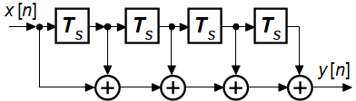

**VORBEREITUNG:**

- Welche Länge $L$ hat die Impulsanwort? $L = 250 us / 15.625 us = 16 $ -> N = L - 1 = 15 (Bei Movingaverage Filter)
- Wie groß ist die Abtastperiode $T_S$? 1/fs = 1/64kHz = 15.625 us

## 2.1 Einschub: Abschnittsweise definierte Funktionen in Python

Allgemein können Sie Funktionen abschnittsweise definieren mit:

### 2.1.1 List Comprehension

Mit einer sogenannten "List Comprehension" können Sie sehr kompakt eine Liste definieren oder modifzieren. Mit `y=[i*i for i in t]` definieren Sie eine Liste mit einer quadratischen Funktion über dem Zeitvektor $t$, mit `y=[i < T_0 for i in t]` eine Liste mit einer Funktion, die 1 ist für $t < T_0$ und ansonsten 0. Dabei wird das schlampige Typecasting von Python genutzt (True -> 1, False -> 0).

List comprehensions ähneln der mathematischen Schreibweise:

$$y = t^2 \text{ für }t \in \mathbb{R} $$

bzw.

$$y = 1 \text{ für }t < T_0, 0 \text{ sonst.} $$

Mit einer zusätzlichen Bedingung kann man auch kompliziertere Funktionen erzeugen wie die Menge der Quadratzahlen aller geraden Zahlen zwischen 10 und 20: `m = [x**2 for x in range(10,21) if x%2 == 0]`. Mathematisch gesehen:

$$ m=\{x^{2}\in \mathbb {N} \,|\,10\leq x\leq 20,\,x \bmod 2 = 0\} $$

### 2.1.2. Schneller mit numpy

Für große Datenmengen und / oder hohe Geschwindigkeit sollte man numpy-Funktionen wie `np.where()` verwenden:

```python
t = np.arange(100) # Array 0 ... 99
h = np.where(t < 25, 1, 0) # 1 für t < 25, ansonsten 0
```

## 2.2 Plotten der Impulsantwort

**SIMULATION:**

Definieren Sie jetzt mit Hilfe einer list comprehension oder der `np.where()` Funktion die Impulsantwort des Filters und plotten Sie sie als `stem()` Plot über der Zeit $t$. Optional überlagern Sie im gleichen Plot den "analogen" Rechteckpuls.

**Tipp:** Sie können das Aussehen des Stemplots ändern z.B. mit `stem(n,y, 'b-', 'ro', 'k')` ('b-' blaue Linien, 'ro' rote Punkte als Marker und 'k' schwarze Grundlinie)

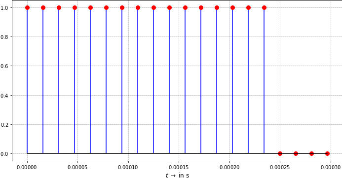

```python
fig, ax = plt.subplots(**size)
T_s = 0.000015625
N = 15
t = np.arange(0,0.0003, T_s)
h = np.where(t <= T_s * N, 1, 0)

ax.stem(t, h, 'b-', 'ro', 'k')
ax.set_xlabel(r"$t \; \rightarrow$ in s");
```

## 2.3 Rauschen als Testsignal

**SIMULATION:**

Hören Sie sich zunächst das Stereorauschen in der nächsten Zelle an. Ersetzen Sie versuchsweise das normalverteilte Rauschen durch gleichverteiltes (uniform) Rauschen `np.random.rand(M,N)`. Hören Sie einen Unterschied? -> Das Normalverteil hört sich flacher an.

```python
x_n = np.random.randn(2,16000)
display(Audio(data=x_n, rate=8000))
x_g = np.random.rand(2,16000)
print("shape x_g: ", np.shape(x_g))
display(Audio(data=x_g, rate=8000))
```

[interactive chart not shown]

```
shape x_g:  (2, 16000)
```

[interactive chart not shown]

**VORBEREITUNG:**

## 2.3 Falten und Plotten

Mit `np.convolve(a,b)` faltet man zwei eindimensionale Arrays, ggf. können Sie ein Array der Form (500,1) mit `np.squeeze(x_n)` in eine "flache Form" bringen oder aus einem mehrdimensionalen Array mit `x_n[:,0]` eine Dimension herausziehen.

**SIMULATION:**

```
shape x_n:  (500,) shape y: (500,)
```

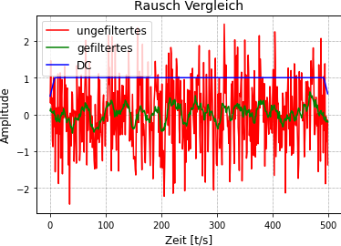

```
shape:  (500,)
```

[interactive chart not shown]

```python
L = 16
x_n = np.squeeze(np.random.randn(500,1))
t = np.arange(len(x_n))

#Filter erstellen
h = np.ones(L) # MA-filter mit Länge L - setzen Sie den passenden Zahlenwert ein
h = h/16 #DC Verstärkung /16

#Signal filtern
y = np.convolve(x_n, h, mode = "same")
y_0 = np.convolve(np.ones(len(x_n)), h, mode = "same")

#Shape and print
print("shape x_n: ", np.shape(x_n), "shape y:", np.shape(y))

#Ploten
plt.plot(t, x_n, color='r', label='ungefiltertes')
plt.plot(t, y, color='g', label='gefiltertes')
plt.plot(t, y_0, color='b', label='DC')

# Naming the x-axis, y-axis and the whole graph
plt.ylabel("Amplitude")
plt.xlabel("Zeit [t/s]")
plt.title("Rausch Vergleich")

# Adding legend, which helps us recognize the curve according to it's color
plt.legend()

# To load the display window
plt.show()

#Audio wiedergabe

print("shape: ", np.shape(y))
display(Audio(data=y.T, rate=16000))
```

## 3. Transferfunktion von LTI-Systemen

Zeitdiskrete Systeme werden in Python und Matlab meistens über die Koeffizienten $a_i$ des rekursiven Teils und die Koeffizienten $b_i$ des nicht-rekursiven Teils angegeben:

$$ H(z) = \frac {Y(z)} {X(z)} = \frac{b_0 + b_1 z^{-1} + b_2 z^{-2} + b_3 z^{-3}}{1 + a_1 z^{-1} + a_2 z^{-2} + a_3 z^{-3}} $$

Aus den Koeffizienten erhält man nämlich sofort den Signalflussgraph in der sog. "Direktform":

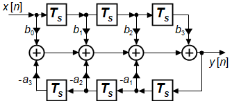

Sie können mit der Software pyfda die Eigenschaften des Systems visualisieren und eigene Filter entwerfen. Im Tab "b,a" importieren Sie Koeffizienten aus einem CSV-File oder (nach Auswahl von "Clipboard" in den Einstellungen) direkt aus der Zwischenablage. Die Koeffizienten `b` des nicht-rekursiven Teils geben Sie hierfür getrennt durch Kommata an, optional in einer zweiten Zeile die Koeffizienten `a` des rekursiven Teils.

Alternativ arbeiten Sie mit dem Notebook LTF-Filter_properties.ipynb, das Ihnen ebenfalls die wichtigsten Eigensschaften darstellt. Aus diesem Notebook können Sie auch leicht Code zum Plotten verschiedener Filtereigenschaften kopieren.

# 3.1 Analyse des Moving Average Filters aus Abschnitt 2

**VORBEREITUNG:**

**SIMULATION:**

- Plotten Sie Betrags- und Phasenfrequenzgang, Gruppenlaufzeit und P/N-Diagramm.

[figure not shown]

### Copyright

(c) 2016 - 2021 Prof. Dr. Christian Münker

This jupyter notebook is part of a collection of notebooks on various topics of Digital Signal Processing. The latest version can be found at https://github.com/chipmuenk/dsp.

This notebook is provided as [Open Educational Resource](https://en.wikipedia.org/wiki/Open_educational_resources). Feel free to use it for your own purposes. The text is licensed under [Creative Commons Attribution 4.0](https://creativecommons.org/licenses/by/4.0/), the code of the IPython examples under the [MIT license](https://opensource.org/licenses/MIT). Please attribute the work as follows: *Christian Münker, Digital Signal Processing - Vorlesungsunterlagen mit Simulationsbeispielen, 2020*.